# Chapter 2 Assignment 2, regression analysis

*Describe the work you have done this week and summarize your learning.*

- Describe your work and results clearly.
- Assume the reader has an introductory course level understanding of writing and reading R code as well as statistical methods.
- Assume the reader has no previous knowledge of your data or the more advanced methods you are using.

```r
date()
```

```
## [1] "Fri Nov  3 16:58:59 2023"
```

I like to list all the needed librarys same place in the beginning of my work/code, so the code cell bellow includes librarys that i will be using.

```r
#Library for reading in and working with the data
library(tidyverse)
```

```r
#Librarys for visualization
library(ggplot2)
library(GGally)
#Library for summarysing the data
library(finalfit)
```

#Preparing the data

First step is to read in the data and make sure that everything looks and is correct. I have set my working directory in IODS-project file (using setwd() -command) so i don’t have to make longer specifications for data location.

The analysis is done by using data from “international survey of Approaches of Learning”. Data that will be used in the analysis is subset of original data, because the original data contains variables that will not be used this time. The subset data includes only 7 variables: gender, age, attitude, deep, stra, surf, points. Gender is character variable (M (Male), F (Female)), age column includes age in years (number), attitude is global attitude towards statistics (scale to 1-5), deep is mean value of questions about deep learning, stra is mean value of questions about strategic learning, surf is mean value of questions about surface learning, and points is amount of points get in the exam (0 points exluded).

```r
#read in the data from data -folder under IODS-project folder
data <- read_csv("data/learning2014.csv")
#check how the data looks by printing first rows
head(data)
```

```
## # A tibble: 6 × 7
##   gender   age attitude  deep  stra  surf points
##   <chr>  <dbl>    <dbl> <dbl> <dbl> <dbl>  <dbl>
## 1 F         53      3.7  3.58  3.38  2.58     25
## 2 M         55      3.1  2.92  2.75  3.17     12
## 3 F         49      2.5  3.5   3.62  2.25     24
## 4 M         53      3.5  3.5   3.12  2.25     10
## 5 M         49      3.7  3.67  3.62  2.83     22
## 6 F         38      3.8  4.75  3.62  2.42     21
```

```r
#the dimensions of the data
dim(data)
```

```
## [1] 166   7
```

```r
#structure of the data
str(data)
```

```
## spc_tbl_ [166 × 7] (S3: spec_tbl_df/tbl_df/tbl/data.frame)
##  $ gender  : chr [1:166] "F" "M" "F" "M" ...
##  $ age     : num [1:166] 53 55 49 53 49 38 50 37 37 42 ...
##  $ attitude: num [1:166] 3.7 3.1 2.5 3.5 3.7 3.8 3.5 2.9 3.8 2.1 ...
##  $ deep    : num [1:166] 3.58 2.92 3.5 3.5 3.67 ...
##  $ stra    : num [1:166] 3.38 2.75 3.62 3.12 3.62 ...
##  $ surf    : num [1:166] 2.58 3.17 2.25 2.25 2.83 ...
##  $ points  : num [1:166] 25 12 24 10 22 21 21 31 24 26 ...
##  - attr(*, "spec")=
##   .. cols(
##   ..   gender = col_character(),
##   ..   age = col_double(),
##   ..   attitude = col_double(),
##   ..   deep = col_double(),
##   ..   stra = col_double(),
##   ..   surf = col_double(),
##   ..   points = col_double()
##   .. )
##  - attr(*, "problems")=<externalptr>
```

Data looks correct and it includes 166 observations and 7 variables. Those variables are “gender, age, attitude, deep, stra, surf, points”. Gender is listed as character and all the other variables are numbers.

To get better view of the data, it is good to visualize it. Visualization is made using ggpairs that creates scatter plot matrix of the variables in the data. In the ggpairs - function first part is to define data that is used, then mapping argument is used to make visualization more appealing. In mapping argument, “col” defines how the points are colored (in this case by gender) and “alpha” defines how transparent the points are. Furthermore the lower argument gives list to the function and the combo part indicates that there are continous and categorial values.

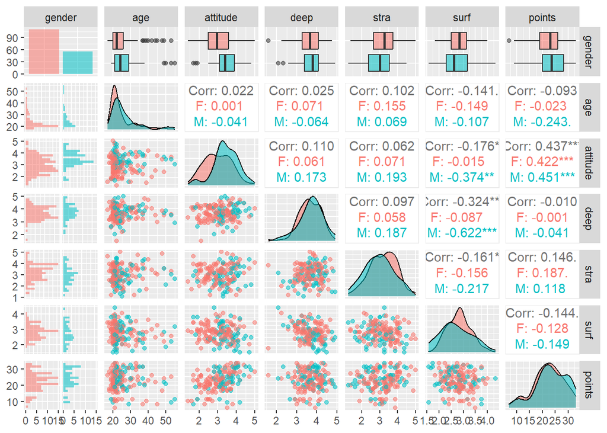

```r
# Create plot using ggpairs that creates scatter plot matrix
visual <- ggpairs(data, mapping = aes(col= gender, alpha = 0.3), lower = list(combo = wrap("facethist", bins = 20)))

# draw the plot
visual
```

Scatter matrix is now showing distribution of the variables and all the correlations between them. Few notes from the data:

Most of the answers are from females (over 90), but there is still about 50 answers from males as well

Most popular age group for both females and males has been between 20-30 years old, but there is few answers from older people as well.

Females responses for attitude are more dispersed, while males responses are more focused on certain values. Overall there is still answer for every attitude value.

Deep learning question answers are weighted towards higher values.

the distribution of strategic learning is closer to the normal distribution.

Surface learning question answers from Females have a clear top, when the male answers have more left skewed answers.

Most of the test takers have scored 20-25 points in the test.

Data does not include any high correlations between variables, so there is no need to change variable selection because of that.

Highest positive correlation is between Points and Attitude (0.437) and highest negative correlation is between Deep learning questions and Surface learning questions (-0.324)

Correlations between variables change depending on the gender and most significant difference is in the deep learning questions and surface learning questions

To get even better view of the data is good also to print out some of the summarys. First command to use is glimpse() -that will show column names, types and first values in that column. Second command is missing_glimpse() -command that will revail if there is missing values. This part will need the library ´finalfit´

```r
#show first rows of each column and the type of the variable
glimpse(data)
```

```
## Rows: 166
## Columns: 7
## $ gender   <chr> "F", "M", "F", "M", "M", "F", "M", "F", "M", "F", "M", "F", "…
## $ age      <dbl> 53, 55, 49, 53, 49, 38, 50, 37, 37, 42, 37, 34, 34, 34, 35, 3…
## $ attitude <dbl> 3.7, 3.1, 2.5, 3.5, 3.7, 3.8, 3.5, 2.9, 3.8, 2.1, 3.9, 3.8, 2…
## $ deep     <dbl> 3.583333, 2.916667, 3.500000, 3.500000, 3.666667, 4.750000, 3…
## $ stra     <dbl> 3.375, 2.750, 3.625, 3.125, 3.625, 3.625, 2.250, 4.000, 4.250…
## $ surf     <dbl> 2.583333, 3.166667, 2.250000, 2.250000, 2.833333, 2.416667, 1…
## $ points   <dbl> 25, 12, 24, 10, 22, 21, 21, 31, 24, 26, 31, 31, 23, 25, 21, 3…
```

```r
#check if there is any missing values
missing_glimpse(data)
```

```
##             label var_type   n missing_n missing_percent
## gender     gender    <chr> 166         0             0.0
## age           age    <dbl> 166         0             0.0
## attitude attitude    <dbl> 166         0             0.0
## deep         deep    <dbl> 166         0             0.0
## stra         stra    <dbl> 166         0             0.0
## surf         surf    <dbl> 166         0             0.0
## points     points    <dbl> 166         0             0.0
```

Data looks good. There is no missing values and all the variable types are correct.

#Regression modelling

I chose to make the model using attitude, strategic and surface learning as explanatory variables.